# Lecture 6: Shell/Perl one-liners

Bruno Contreras Moreira

Fundación ARAID & Estación Experimental de Aula Dei-CSIC, Zaragoza España http://www.eead.csic.es/compbio

17/abr/2018

# 1 Introduction

In Genomics and Computational Biology it is common to handle large datasets, which are often encoded in file formats such as FASTQ, FASTA, etc. Files in these formats are often so bulky that they are compressed to save disk space. Moreover, users of these files might only have remote access to them and therefore are required to operate with them with technologies compatible with the the SSH protocol. The most flexible of them is the terminal, which is easily reachable in Linux, but also MacOS and Windows systems.

## 1.1 Target

The main goal of this lecture is to learn the basics of Perl one-liners when dealing with data files in the terminal.

## 1.2 Dependencies

We will use Perl and Git in this lecture. You can check whether they are installed in your system by typing in the terminal:

```bash
perl --version

git --version
```

```
(with 68 registered patches, see perl -V for more detail)

Copyright 1987-2015, Larry Wall

Perl may be copied only under the terms of either the Artistic License or the
GNU General Public License, which may be found in the Perl 5 source kit.

Complete documentation for Perl, including FAQ lists, should be found on
this system using "man perl" or "perldoc perl".  If you have access to the
Internet, point your browser at http://www.perl.org/, the Perl Home Page.

git version 2.7.4
```

### 1.2.1 Perl

We will use [Perl5](http://www.perl.org/about.html), a classic programming language which is very powerful for the task of processing data files at the terminal. Perl is [installed by default](https://www.perl.org/get.html) in Linux, including macOS, but not in MS Windows. However, it is [easy to install in these systems](https://www.perl.org/get.html#win32) as well. My preference for casual Windows users is to install [MobaXterm](https://mobaxterm.mobatek.net), as this provides a Linux-like terminal and a package manager which we can use to install other required parts, such as Git (see below) or a subset of Perl modules. If full access to modules in CPAN is desired then a stand-alone Strawberry/ActiveState install should be preferred.

[figure not shown]

In order to install Perl under MobaXterm please push “Packages” and select “perl”.

### 1.2.2 Git

Git is a popular distributed version control software which is very common in Bioinformatics. It can be very useful to install and update third-party software. Follow these instructions to install Git:

```bash
# Ubuntu
sudo apt-get install git

# MacOSX: install Xcode Command Line Tools by typing
git --version

# MobaXterm: push "Packages" and select "git"
```

### 1.2.3 Optional software

Some of the examples below make use of optional dependencies, which in Ubuntu systems can be installed as follows:

```bash
sudo apt-get install bioperl r-base

# for optional Perl modules
sudo cpan App::cpanminus
cpanm HTTP::Server::Brick
```

To install bioperl in other systems please see http://bioperl.org/INSTALL.html.

### 1.2.4 Sample data files

If *git* was succesfully installe the following command will download the sample data which will be used in this lecture. These files can be also directly downloaded from [https://github.com/eead-csic-compbio/methods_biostats_bioinfo](https://github.com/eead-csic-compbio/methods_biostats_bioinfo/archive/master.zip):

```bash
git clone https://github.com/eead-csic-compbio/methods_biostats_bioinfo.git
```

## 1.3 Key file formats

### 1.3.1 FASTA

```bash
>transcript XYZ
AAGAATTACAAACCTCAACAACTCTCGACTGTTACAGGCATCGCTGCCATAATATGAGTA
GAGTACATGGGCATCACCTAAATTCTGTGAGCGCCATCCATCAAACTATGTCTGACTGAC
TTGACTGTCTACTACAAGATATACTCATTCTCAATTACATGACGCTTTGACATAATGAGT
GCAAGAAAAATCTACTGATACATCATCACCAAACACACCAACCTAGATTTCCAAGAATCG
TCAATTCAAAACAAGAAACGCTAGAAACAACCTAATCAGATGCAATTATTATTCTTCCTC
TTGTTATGTCGTGAAGAAAGACCATAGCGTTTTCCCAATCGATTTGTTTCGC

>gi|5524211|gb|AAD44166.1| cytochrome b [Elephas maximus maximus]
LCLYTHIGRNIYYGSYLYSETWNTGIMLLLITMATAFMGYVLPWGQMSFWGATVITNLFSAIPYIGTNLV
EWIWGGFSVDKATLNRFFAFHFILPFTMVALAGVHLTFLHETGSNNPLGLTSDSDKIPFHPYYTIKDFLG
LLILILLLLLLALLSPDMLGDPDNHMPADPLNTPLHIKPEWYFLFAYAILRSVPNKLGGVLALFLSIVIL
GLMPFLHTSKHRSMMLRPLSQALFWTLTMDLLTLTWIGSQPVEYPYTIIGQMASILYFSIILAFLPIAGX
IENY*

>Homeobox protein hox-b1 (part of P40424|PBX1_HUMAN)
MEPNTPTART FDWMKVKRNP PKTAKVSEPG LGSPSGLRTN FTTRQLTELE
KEFHFNKYLS RARRVEIAAT LELNETQVKI WFQNRRMKQK KREREGG
```

### 1.3.2 FASTQ

This is the standard format for high-throughput sequencing reads. Each read takes four lines, with headers starting with char @. Note that in this example pair-end reads are interleaved, with read 2 of each pair coming just after read 1:

```bash
@SRR491411.1.1 HWUSI-EAS1737_0007:6:1:1007:2418 length=101
NCTACCGATGAGCCCGAAACTTTTCCGGTAATGCACGAAAACCTTCCGGTAACCAAATGAGGTCATCCTCTATCTCAATCTTCCATTCCGGACCATTCCGG
+SRR491411.1.1 HWUSI-EAS1737_0007:6:1:1007:2418 length=101
#*4*+000/0;???>@@<?<<9<<<=>8=;4+888>>>>><A@@?########################################################
@SRR491411.1.2 HWUSI-EAS1737_0007:6:1:1007:2418 length=101
ATATGGGCATCCAGGTCCCGCTATTGGATATTGACCGAGGAGTCTCTCGGGTCATGTCTACATAGTTCTCGAACCCGCAGGGACTGCACAACTAAGGTTGG
+SRR491411.1.2 HWUSI-EAS1737_0007:6:1:1007:2418 length=101
DEDBEE?:E?D5CDA@ACAA=E=D5D?5BCAA:-=5C5?C:?*A>BB?EC??D??CBB5=,/)775><>>B?-C?##########################
```

Check our [blog post](https://bioinfoperl.blogspot.com.es/2014/12/perl-module-kseqklib-parse-fastq-fasta-files.html) on highly efficient ways of parsing these files.

### 1.3.3 BLAST tab-separated format

The 12-column format below is produced by BLAST when option **-outfmt 6** is in use; columns are **tab-separated** in the [following order](https://www.ncbi.nlm.nih.gov/books/NBK279684): *qseqid sseqid pident length mismatch gapopen qstart qend sstart send evalue bitscore*

```bash
1   1   100.00  628 0   0   1   628 1   628 0.0 1281
1   4102    64.63   622 220 0   1   622 1   622 0.0  852
1   5262    60.61   622 245 0   1   622 1   622 0.0  812
1   7852    61.09   622 242 0   1   622 1   622 0.0  818
1   13947   60.29   622 245 1   7   628 7   626 0.0  767
1   17697   64.79   622 219 0   1   622 1   622 0.0  853
2   2   100.00  274 0   0   1   274 1   274 2e-154   544
```

### 1.3.4 SAM

The format below contains at least 11 **tab-separated** columns in the following order: *QNAME, FLAG, RNAME, POS, MAPQ, CIGAR, RNEXT, PNEXT, TLEN, SEQ, QUAL*

```bash
@SQ    SN:chr1    LN:50
read1    16    chr1    1    255    50M    *    0    0    ATTTAAAAATTAATTTAATGCTTGGCTAAATCTTAATTACATATATAATT   <<<<<<<<<<<<<<<<<<<<<<<<<<<<<<<<<<<<<<<<<<<<<<<<<<    NM:i:0
read1    1032    chr1    1    255    50M    *    0    0    ATTTAAAAATTAATTTAATGCTTGGCTAAATCTTAATTACATATATAATT   <<<<<<<<<<<<<<<<<<<<<<<<<<<<<<<<<<<<<<<<<<<<<<<<<<    NM:i:0
```

The binary version of SAM is called BAM, and can be queried with software [samtools](http://www.htslib.org/doc/samtools.html).

### 1.3.5 VCF

The Variant Call Format was designed to summarize genetic variations mapped on a reference genome/sequence:

```bash
##fileformat=VCFv4.0
##fileDate=20090805
##source=myImputationProgramV3.1
##reference=1000GenomesPilot-NCBI36
##phasing=partial
##INFO=<ID=NS,Number=1,Type=Integer,Description="Number of Samples With Data">
##INFO=<ID=DP,Number=1,Type=Integer,Description="Total Depth">
##INFO=<ID=AF,Number=.,Type=Float,Description="Allele Frequency">
##INFO=<ID=AA,Number=1,Type=String,Description="Ancestral Allele">
##INFO=<ID=DB,Number=0,Type=Flag,Description="dbSNP membership, build 129">
##INFO=<ID=H2,Number=0,Type=Flag,Description="HapMap2 membership">
##FILTER=<ID=q10,Description="Quality below 10">
##FILTER=<ID=s50,Description="Less than 50% of samples have data">
##FORMAT=<ID=GT,Number=1,Type=String,Description="Genotype">
##FORMAT=<ID=GQ,Number=1,Type=Integer,Description="Genotype Quality">
##FORMAT=<ID=DP,Number=1,Type=Integer,Description="Read Depth">
##FORMAT=<ID=HQ,Number=2,Type=Integer,Description="Haplotype Quality">
#CHROM POS     ID        REF ALT    QUAL FILTER INFO                              FORMAT      NA00001        NA00002        NA00003
20     14370   rs6054257 G      A       29   PASS   NS=3;DP=14;AF=0.5;DB;H2           GT:GQ:DP:HQ 0|0:48:1:51,51 1|0:48:8:51,51 1/1:43:5:.,.
20     17330   .         T      A       3    q10    NS=3;DP=11;AF=0.017               GT:GQ:DP:HQ 0|0:49:3:58,50 0|1:3:5:65,3   0/0:41:3
20     1110696 rs6040355 A      G,T     67   PASS   NS=2;DP=10;AF=0.333,0.667;AA=T;DB GT:GQ:DP:HQ 1|2:21:6:23,27 2|1:2:0:18,2   2/2:35:4
20     1230237 .         T      .       47   PASS   NS=3;DP=13;AA=T                   GT:GQ:DP:HQ 0|0:54:7:56,60 0|0:48:4:51,51 0/0:61:2
20     1234567 microsat1 GTCT   G,GTACT 50   PASS   NS=3;DP=9;AA=G                    GT:GQ:DP    0/1:35:4       0/2:17:2       1/1:40:3
```

The binary version of VCF is called BCF, and can be queried with software [bcftools](https://samtools.github.io/bcftools/bcftools.html).

### 1.3.6 PDB

The classic Protein Data Bank format, as well as the [updated PDBx variant](https://bioinfoperl.blogspot.com.es/2017/10/formato-pdbxmmcif-protein-data-bank.html), are used to annotate and describe the positions of atoms in macromolecules such as proteins, DNA and RNA:

```bash
ATOM      1  O5'  DG A   1      13.136  26.426  -2.541  1.00 15.00           O
ATOM      2  C5'  DG A   1      11.802  26.362  -2.030  1.00 15.00           C
ATOM      3  C4'  DG A   1      11.520  25.005  -1.428  1.00 15.00           C
ATOM      4  O4'  DG A   1      10.541  24.330  -2.241  1.00 15.00           O
ATOM      5  C3'  DG A   1      12.726  24.064  -1.369  1.00 15.00           C
ATOM      6  O3'  DG A   1      12.764  23.394  -0.106  1.00 15.00           O
ATOM      7  C2'  DG A   1      12.495  23.060  -2.494  1.00 15.00           C
ATOM      8  C1'  DG A   1      11.234  23.552  -3.188  1.00 15.00           C
ATOM      9  N9   DG A   1      11.483  24.384  -4.360  1.00 15.00           N
ATOM     10  C8   DG A   1      12.655  25.014  -4.698  1.00 15.00           C
ATOM     11  N7   DG A   1      12.579  25.674  -5.822  1.00 15.00           N
ATOM     12  C5   DG A   1      11.275  25.473  -6.250  1.00 15.00           C
ATOM     13  C6   DG A   1      10.606  25.944  -7.409  1.00 15.00           C
ATOM     14  O6   DG A   1      11.047  26.655  -8.319  1.00 15.00           O
ATOM     15  N1   DG A   1       9.287  25.503  -7.453  1.00 15.00           N
ATOM     16  C2   DG A   1       8.687  24.712  -6.503  1.00 15.00           C
ATOM     17  N2   DG A   1       7.404  24.394  -6.723  1.00 15.00           N
ATOM     18  N3   DG A   1       9.301  24.266  -5.419  1.00 15.00           N
ATOM     19  C4   DG A   1      10.583  24.683  -5.357  1.00 15.00           C
```

### 1.3.7 Newick

The Newick format does the job of describing a phylogenetic tree as a sucession of nodes, branches, and distances:

```bash
((((((((((BsyC:0.013358,BsyE:0.021549):0.090257,BsyG:0.027746):0.012743,Bpin:0.080853):0.015246,((B422:0.015850,Bpho:0.017473):0.034584,Brup:0.01
8335):0.025314):0.018883,Barb:0.108741):0.045155,((Bboi:0.115276,Bret:0.042738):0.050086,Bmex:0.153381):0.040856):0.159346,((Bdis:0.039945,Bhyb:0
.042164):0.016188,Bsta:0.054611):0.072495):0.093114,Osat:0.177214):0.071042):0.035521,Sbic:0.035521);
```

# 2 Perl

## 2.1 Perl basics in 5 minutes

The following snippet illustrates the main features you must know in order to read and write Perl code. One of the strongest features of Perl are its [regular expressions](https://perldoc.perl.org/perlre.html), which are efficient and powerful:

```perl
# This is a comment

# Adapted from https://learnxinyminutes.com/docs/perl

#### Strict and warnings

use strict;
use warnings;

# All perl scripts and modules should include these lines. Strict causes
# compilation to fail in cases like misspelled variable names, and
# warnings will print warning messages in case of common pitfalls like
# concatenating to an undefined value.

#### Perl variable types

#  Variables begin with a sigil, which is a symbol showing the type.
#  A valid variable name starts with a letter or underscore,
#  followed by any number of letters, numbers, or underscores.

### Perl has three main variable types: $scalar, @array, and %hash.

## Scalars
#  A scalar represents a single value:
my $animal = "camel";
my $answer = 42;
my $display = "You have $answer ${animal}s.\n";

# Scalar values can be strings, integers or floating point numbers, and
# Perl will automatically convert between them as required.

# Strings in single quotes are literal strings. Strings in double quotes
# will interpolate variables and escape codes like "\n" for newline.

## Arrays
#  An array represents a list of values:
my @animals = ("camel", "llama", "owl");
my @numbers = (23, 42, 69);
my @mixed   = ("camel", 42, 1.23);

# Array elements are accessed using square brackets, with a $ to
# indicate one value will be returned.
my $second = $animals[1];

# The size of an array is retrieved by accessing the array in a scalar
# context, such as assigning it to a scalar variable or using the
# "scalar" operator.

my $num_animals = @animals;
print "Number of numbers: ", scalar(@numbers), "\n";

# Be careful when using double quotes for strings containing symbols
# such as email addresses, as it will be interpreted as a variable.

my @example = ('secret', 'array');
my $oops_email = "foo@example.com"; # 'foosecret array.com'
my $ok_email = 'foo@example.com';

## Hashes
#   A hash represents a set of key/value pairs:

my %fruit_color = ("apple", "red", "banana", "yellow");

#  You can use whitespace and the "=>" operator to lay them out more
#  nicely:

my %fruit_color = (
  apple  => "red",
  banana => "yellow",
);

# Hash elements are accessed using curly braces, again with the $ sigil.
my $color = $fruit_color{apple};

# All of the keys or values that exist in a hash can be accessed using
# the "keys" and "values" functions.
my @fruits = keys %fruit_color;
my @colors = values %fruit_color;

# Scalars, arrays and hashes are documented more fully in perldata.
# (perldoc perldata).

#### Conditional and looping constructs

# Perl has most of the usual conditional and looping constructs.

if ($var) {
  ...
} elsif ($var eq 'bar') {
  ...
} else {
  ...
}

# the Perlish post-condition way
print "Yow!" if $zippy;
print "We have no bananas" unless $bananas;

#  while
while (condition) {
  ...
}


# for loops and iteration
for my $i (0 .. $max) {
  print "index is $i";
}

for my $element (@elements) {
  print $element;
}

map {print} @elements;

# iterating through a hash (for and foreach are equivalent)

foreach my $key (keys %hash) {
  print $key, ': ', $hash{$key}, "\n";
}

#### Regular expressions

# Perl's regular expression support is both broad and deep, and is the
# subject of lengthy documentation in perlrequick, perlretut, and
# elsewhere. However, in short:

# Simple matching
if (/foo/)       { ... }  # true if $_ contains "foo"
if ($x =~ /foo/) { ... }  # true if $x contains "foo"

# Simple substitution

$x =~ s/foo/bar/;         # replaces foo with bar in $x
$x =~ s/foo/bar/g;        # replaces ALL INSTANCES of foo with bar in $x
```

## 2.2 Perl one-liners

A one-liner is a Perl program in which the source code is typed in the terminal instead of being contained in a file. Their main advantage is that they can be naturally combined with powerful command-line Linux such as *grep, sort or uniq*. In the next sections we will show how to write some useful one-liners. The reader can learn even more from repositories such as [perl_the_swiss_knife](https://learnbyexample.gitbooks.io/command-line-text-processing/content/perl_the_swiss_knife.html), [perl-one-liners](https://gist.github.com/mischapeters/1e8eef09a0aafd4f24f0) or [Perl one-liners](https://gist.github.com/joyrexus/7328094). Occasionally we post one-liners at out [blog](https://bioinfoperl.blogspot.com.es).

### 2.2.1 Hello world one-liners

One-liners are executed by calling the interpreter with option *-e* and some Perl syntax between ‘single quotes’:

```bash
perl -e 'print "hello world"'
echo

# -l adds newline char '\n' to each output line
perl -le 'print "hello world"'
echo

# add -n to read input file line by line ($_ = current line)
gunzip test_data/test.fasta.gz
perl -lne 'print $_ if(/ATGATGATG/)' test_data/test.fasta
echo

# now in reverse order
tac test_data/test.fasta | perl -lne 'print $_ if(/ATGATGATG/)'
gzip test_data/test.fasta
echo

# if input is gzipped a pipe (|) can be used
# NOTE this is equivalent tozcat test_data/test.fasta.gz | grep -P "^>"
zcat test_data/test.fasta.gz | perl -lne 'print if(/^>/)'
```

```
hello world
hello world

CAATAGCTAAATGATGATGAGCAATATCGGTCAGCCACAAACTTTGCGTTTGTGGATGGA
ATACGTTTTATTGATTTTGGAATTGACATAGATACAAATACTCTACTATGATGATGCACA
AAATGCAATAGCTAAATGATGATGAGCAATATCGGTCAGCCACAAACTTTGTGTTTGTGG
AATGATGATGAGCAATATCGGTCAGCCACAAACTTTGTGTTTGTGGATGGAATCCCCCAA
GATACATATGACCGGCAATGAGAAAAATAAATGCAATAGCTAAATGATGATGAGCAATAT
AATAGCTAAATGATGATGAGCAATATCGGTCAGCCACAAACTTTGTGTTTGTGGATGGAA
AGCTAAATGATGATGAGCAATATCGGTCAGCCACAAACTTTGTGTTTGTGGATGGAATCC
TCGATACATATGACCGGCAATGAGAAAAATAAATGCAATAGCTAAATGATGATGAGCAAT

TCGATACATATGACCGGCAATGAGAAAAATAAATGCAATAGCTAAATGATGATGAGCAAT
AGCTAAATGATGATGAGCAATATCGGTCAGCCACAAACTTTGTGTTTGTGGATGGAATCC
AATAGCTAAATGATGATGAGCAATATCGGTCAGCCACAAACTTTGTGTTTGTGGATGGAA
GATACATATGACCGGCAATGAGAAAAATAAATGCAATAGCTAAATGATGATGAGCAATAT
AATGATGATGAGCAATATCGGTCAGCCACAAACTTTGTGTTTGTGGATGGAATCCCCCAA
AAATGCAATAGCTAAATGATGATGAGCAATATCGGTCAGCCACAAACTTTGTGTTTGTGG
ATACGTTTTATTGATTTTGGAATTGACATAGATACAAATACTCTACTATGATGATGCACA
CAATAGCTAAATGATGATGAGCAATATCGGTCAGCCACAAACTTTGCGTTTGTGGATGGA

>NC_015820 Acidosasa purpurea chloroplast, complete genome.
>NC_008591 Agrostis stolonifera chloroplast, complete genome.
>NC_014062 Anomochloa marantoidea chloroplast, complete genome.
>NC_015830 Bambusa emeiensis chloroplast, complete genome.
>NC_012927 Bambusa oldhamii chloroplast, complete genome.
>NC_011032 Brachypodium distachyon chloroplast, complete genome.
>NC_013273 Coix lacryma-jobi chloroplast, complete genome.
>NC_013088 Dendrocalamus latiflorus chloroplast, complete genome.
>NC_015831 Ferrocalamus rimosivaginus plastid, complete genome.
>NC_011713 Festuca arundinacea chloroplast, complete genome.
>EF115541 Hordeum vulgare subsp. vulgare cultivar Morex chloroplast, complete genome.
>NC_015803 Indocalamus longiauritus plastid, complete genome.
>NC_009950 Lolium perenne chloroplast, complete genome.
>AY522329 Oryza sativa (indica cultivar-group) isolate 93-11 chloroplast, complete genome.
>AY522331 Oryza sativa (japonica cultivar-group) isolate PA64S chloroplast, complete genome.
>NC_015990 Panicum virgatum chloroplast, complete genome.
>NC_015817 Phyllostachys edulis chloroplast, complete genome.
>NC_015826 Phyllostachys nigra var. henonis chloroplast, complete genome.
>NC_006084 Saccharum hybrid cultivar NCo 310 chloroplast, complete genome.
>NC_008602 Sorghum bicolor chloroplast, complete genome.
>NC_002762 Triticum aestivum chloroplast, complete genome.
>X86563 Zea mays complete chloroplast genome.
```

### 2.2.2 One-liners that count input lines

Perl global variable $. contains at any moment the current input line number. In this example we used to print the first line every four lines of a FASTQ file:

```bash
zcat test_data/testPE.fastq.gz | perl -lne 'print if($.%4==1)' | head -10
```

```
@711:1:1:0:236/1
@711:1:1:0:236/2
@711:1:1:0:1828/1
@711:1:1:0:1828/2
@711:1:1:1:164/1
@711:1:1:1:164/2
@711:1:1:1:1466/1
@711:1:1:1:1466/2
@711:1:1:1:1754/1
@711:1:1:1:1754/2
```

### 2.2.3 Split-column one-liners

Option *-a* should be used to split input lines in columns and save teh resulting elements in array @F:

```bash
# parse 12-column TSV BLAST output and select hits of sequence "12" with some E-value cutoff
zcat test_data/test.blast.tsv.gz | perl -lane 'print $F[1] if($F[0] eq "12" && $F[10] < 0.0001)'
echo

# use -F to change column separator
zcat test_data/test.blast.tsv.gz | perl -F'\s+' -lane 'print "$F[0] $F[1]" if($F[10] < 0.0001)' | wc
echo

# combine with efficient system sort
zcat test_data/test.blast.tsv.gz | sort -nk1,1 -nk2,2 -nk1,1 | \
  perl -lane 'print $F[1] if($F[0] eq "12" && $F[10] < 0.0001)'
```

```
12
4062
17662
18387
37930
41980
7527
8382
5669
22821
27133
31312
36972
39333
2932
16362
5881
9330
6383

  90681  181362  940129

12
2932
4062
5669
5881
6383
7527
8382
9330
16362
17662
18387
22821
27133
31312
36972
37930
39333
41980
```

### 2.2.4 One-liners calling modules

Sometimes modules are required in one-liners. Core modules are pre-installed in most systems:

```bash
# List::Util is a core module
echo '34,17,6' | perl -MList::Util=max -F"," -lane 'print max @F'
```

```
34
```

Other modules must be instaleld before they can be used:

```bash
# HTTP::Server::Brick must be installed
# this serves the current folder to share data through the Web
perl -MHTTP::Server::Brick -e '$s=HTTP::Server::Brick->new(port=>8000); $s->mount("/"=>{path=>"."}); $s->start'
```

### 2.2.5 *In situ* edition of files with regular expressions (regexes)

Flag *-i* allows the edition of text files *in situ*, creating backups:

```bash
gunzip test_data/test.fasta.gz
perl -i.bk -ne 's/, complete genome\.//; print' test_data/test.fasta
```

### 2.2.6 One-liners that use range regexes

The next example prints lines that appear in the input file after the first regex and before the second:

```bash
zcat test_data/test.blast.tsv.gz | perl -lne 'print if /^10\t/../^12\t/'
```

```
10  10  100.00  803 0   0   1   803 1   803 0.0 1640
10  4059    62.11   805 302 2   1   803 1   804 0.0 1064
10  5246    57.68   801 334 4   5   803 9   806 0.0  959
10  7843    60.67   801 310 4   5   803 9   806 0.0 1006
10  8385    54.91   805 356 5   3   803 5   806 0.0  924
10  17659   61.99   805 303 2   1   803 1   804 0.0 1065
10  18390   59.88   810 313 8   1   803 1   805 0.0 1001
10  22225   58.66   808 324 4   1   803 1   803 0.0  956
10  22824   49.76   818 374 9   5   803 15  814 0.0  816
10  27136   49.82   819 372 9   5   803 15  814 0.0  818
10  31316   50.92   811 378 6   3   803 14  814 0.0  811
10  37927   60.75   805 313 2   1   803 1   804 0.0 1050
10  41977   60.75   805 313 2   1   803 2   805 0.0 1051
10  28800   39.29   560 319 8   1   554 6   550 9e-111   401
10  24509   39.46   560 318 8   1   554 1   545 1e-110   401
```

[output cut: 23 more lines]

### 2.2.7 One-liner output piped to other process

In this example a histogram is computed in R from data parsed with Perl one-liner:

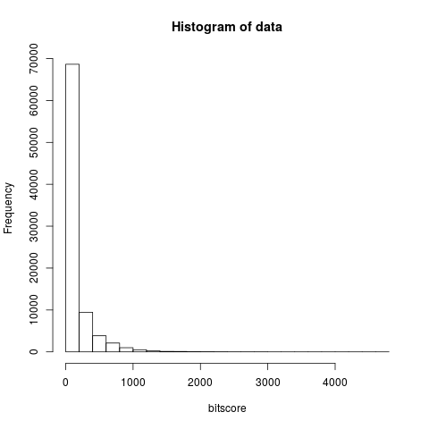

```bash
# this requires R installed and produces a PDF file
zcat test_data/test.blast.tsv.gz | perl -lane 'print $F[11] if($F[10] < 0.00001)' | \
  Rscript -e 'data=abs(scan(file="stdin")); pdf("bits.pdf"); hist(data,xlab="bitscore")'
```

### 2.2.8 Some bioinformatics one-liners

```bash
# find palindromes
zcat test_data/test.fasta.gz | perl -lne 'print if($_ eq reverse)'
echo

# convert FASTA file so that sequences take a single line (order changes)
# NOTE that END{} is used to do operations after input is consumed
zcat test_data/test.fasta.gz | \
  perl -lne 'if(/^(>.*)/){ $h=$1 } else { $fa{$h} .= $_ } END{ foreach $h (keys(%fa)){ print "$h\n$fa{$h}\n" }}' \
  > test_data/test.1.fasta

# compute frequency of 6-mers, print 10 random hexamers
perl -lne 'if(!/^>/){ while(/(\w{6})/g){$fq{$1}++}} END{ foreach $k (keys(%fq)){ print "$k $fq{$k}" }}' test_data/test.1.fasta | head -10
echo

# print top 6-mers
perl -lne 'if(!/^>/){ while(/(\w{6})/g){$fq{$1}++}} END{ foreach $k (sort {$fq{$b}<=>$fq{$a}} keys(%fq)){ print "$k $fq{$k}" }}' test_data/test.1.fasta | head -10
```

```
AA

CTGACG 24
GGCAGG 41
AGAACC 173
AGTCTA 93
ACCTAG 70
TAGGGT 90
ATGGCT 102
ACTAGA 117
TGCATA 119
GTCTGG 52

AAAAAA 1703
TTTTTT 1630
AAAAAG 978
AAAGAA 934
CTTTTT 897
TTCTTT 895
AAGAAA 894
TTTCTT 881
AAAAGA 860
TTTTTC 844
```

If [Bio::Perl](http://bioperl.org) is installed in your system you can use one-liners to download and format sequences from databases:

```bash
# Bio::Perl must be installed
perl -MBio::Perl -e '$gb=get_sequence("genbank","CP000524"); write_sequence(">CP000524.fna","fasta",$gb)'
```

### 2.2.9 Writing complete programs in Perl

There are many tutorials available online in English. A good place to start might be: https://perlmaven.com/perl-tutorial

If you prefer Spanish, I maintain my own tutorial on Perl on Bioinformatics, which you can find at: https://eead-csic-compbio.github.io/perl_bioinformatica